# Statistical Inference Project: Part 1 - Simulation Exercise

Mariana

05/02/2018

## Overview:

This project investigates the Exponential distribution, which can be simulated in R with `rexp(n, lambda)` where lambda is the rate parameter, and compares it with the Central Limit Theorem.

The mean of the Exponential distribution is $\frac{1}{\lambda}$ and the standard deviation is also $\frac{1}{\lambda}$.

$\lambda$ will be set to 0.2 for all simulations, a thousand simulations of the distribution of 40 exponentials will be investigated.

## Simulations:

The exponential distribution can be simulated in R with `rexp(n, lambda)`, where `lambda` is the rate parameter and `n` is the number of observations.

There following steps were performed:

- Setting seed (so that the analysis is reproducible) and parameter values.
- Values are arranged in a matrix `simulMatrix` with with thousand rows corresponding to 1000 simulations and forty columns corresponding to each of 40 random simulations.
- Then the mean of each row is computed, values are stored in the vector of 1000 rows `simulMean`.
- Subsequently, a data frame `AllData` is created containing the whole data.
- Finally plot the simulation data to visualize it. A vertical red line at the mean of the sample means have been aded. Please note that `ggplot2` was used to perform this step

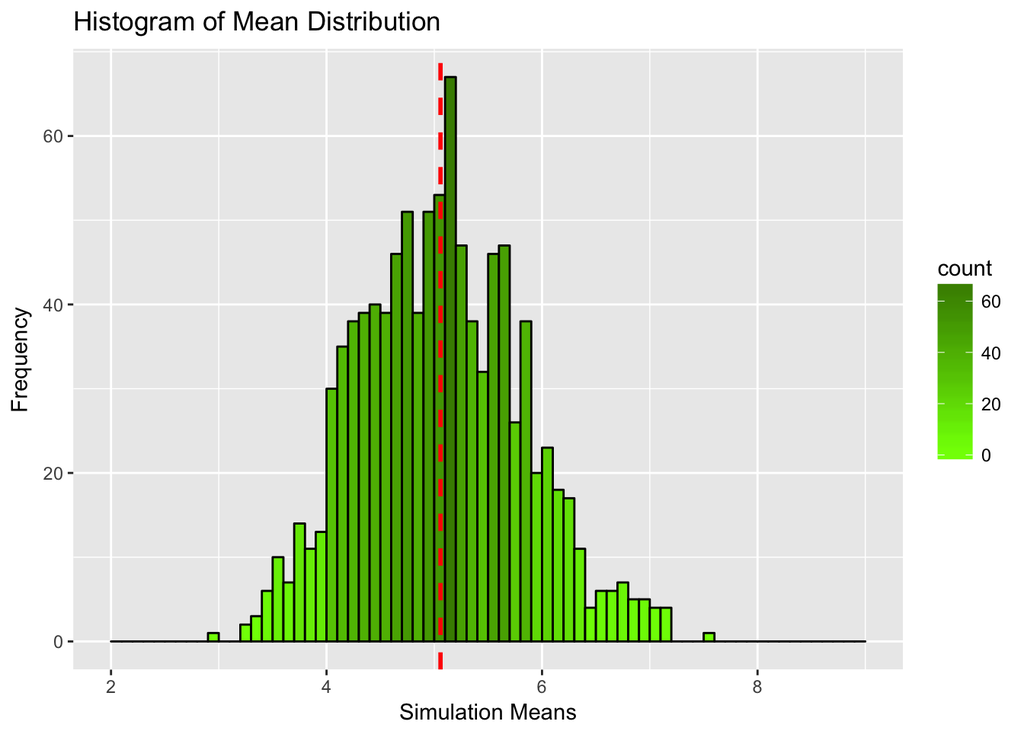

```r
library(ggplot2)

set.seed(050218)
lambda <- 0.2
n <- 40
sim <- 1000
average <- NULL

# matrix
simulMatrix <- matrix(rexp(n = sim * n, rate = lambda), sim, n)

# mean
simulMean <- rowMeans(simulMatrix)

# Data Frame
AllData <- data.frame(cbind(simulMatrix, simulMean))

ggplot(data = AllData, aes(AllData$simulMean)) +
  geom_histogram(breaks = seq(2, 9, by = 0.1), col = "black", aes(fill = ..count..)) +scale_fill_continuous(low="chartreuse1", high="chartreuse4") +
  labs(title = "Histogram of Mean Distribution", x = "Simulation Means", y = "Frequency") +
  geom_vline(aes(xintercept=mean(AllData$simulMean)), color="red",
             linetype="dashed", size=1)
```

## Sample Mean versus Theoretical Mean

As stated in the `Overview`, the expected mean $\mu$ of a exponential distribution of rate $\lambda$ is

$\mu= \frac{1}{\lambda}$

```r
mu <- 1/lambda
mu
```

```
## [1] 5
```

Let $\bar X$ be the average sample mean of 1000 simulations of 40 randomly sampled exponential distributions.

```r
meanOfMeans <- mean(simulMean)
meanOfMeans
```

```
## [1] 5.057746
```

It is clear that the theoretical mean of the distribution $\mu= \frac{1}{\lambda}$ and the sample mean of the distribution $\bar X$ are similar. The difference between both is very small.

```r
cat( cat("sample mean: ", round(meanOfMeans, 2)),
     cat("\ntheoretical mean: ", mu))
```

```
## sample mean:  5.06
## theoretical mean:  5
```

## Sample Variance versus Theoretical Variance

$\sigma = \frac{1/\lambda}{\sqrt{n}}$

And

$Var = \sigma^2$

Let $actVar$ be the variance of the average sample mean of 1000 simulations of 40 randomly sampled exponential distribution, and $theoryVar$ be the theoretical variance.

```r
actVar <- var(simulMean)
actVar
```

```
## [1] 0.5769862
```

```r
theoryVar <- ((1 / lambda) ^2) / n
theoryVar
```

```
## [1] 0.625
```

The variances are very close, with small difference between them.

```r
cat((paste("Theoretical variance: ", round(theoryVar, 2))),
    (paste("\nPractical variance: ", round(actVar ,2))))
```

```
## Theoretical variance:  0.62
## Practical variance:  0.58
```

## Distribution

The simulated mean sample data approximatelly follow the Normal distribution. This can be demonstrated below: Please note, `ggplot2` has been used.

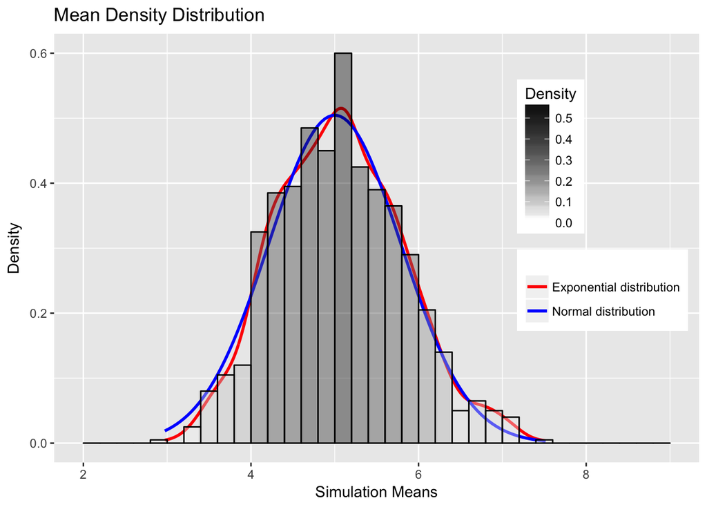

```r
qplot(simulMean, geom = 'blank') +
  geom_line(aes(y=..density.., colour='Exponential distribution'), stat='density', size=1) +
  stat_function(fun=dnorm, args=list(mean=(1/lambda), sd=((1/lambda)/sqrt(n))),
                aes(colour='Normal distribution'), size=1) +
  geom_histogram(aes(y=..density.., fill=..density..), alpha=0.4,
                 breaks = seq(2, 9, by = 0.2), col='black') +
  scale_fill_gradient("Density", low = "white", high = "black") +
  scale_color_manual(name='', values=c('red', 'blue')) +
  theme(legend.position = c(0.85, 0.60)) +
  labs(title = "Mean Density Distribution", x = "Simulation Means", y = "Density")
```

Red line indicate the exponential distribution of the sample and the blue line is the theoretical normal distribution. The calculated distribution of the means overlaps with the normal distribution.